# Assignment 5

Ana Zhibaj

```r
library(tidyverse)
library(ggthemes)
library(jtools)
library(interactions)
library(knitr)
```

I changed some of the variables from the previous assignment, namely I reduced the number of categories for Education and Employment status. They offered a level of specificity that did not contribute to my research question. I have filtered the variable for Race, excluding the category “No data”, and Employment, excluding the category “Not in labor force”.

```r
citizenship_data <- read_csv("Citizenship-class-race-updated.csv") %>%
  mutate(SCHL_label = case_when(
    SCHL_label=="1 or more years of college credit, no degree"~"1HS Graduate or lower", # I added 1 in front of the base category.
    SCHL_label=="12th grade - no diploma"~"1HS Graduate or lower",
    SCHL_label=="Associate's degree"~"Associate's degree",
    SCHL_label=="Bachelor's degree"~"Bachelor's degree or Higher",
    SCHL_label=="Doctorate degree"~"Bachelor's degree or Higher",
    SCHL_label=="GED or alternative credential"~"1HS Graduate or lower",
    SCHL_label=="Grade 10"~"1HS Graduate or lower",
    SCHL_label=="Grade 11"~"1HS Graduate or lower",
    SCHL_label=="Grade 1"~"1HS Graduate or lower",
    SCHL_label=="Grade 2"~"1HS Graduate or lower",
    SCHL_label=="Grade 3"~"1HS Graduate or lower",
    SCHL_label=="Grade 4"~"1HS Graduate or lower",
    SCHL_label=="Grade 5"~"1HS Graduate or lower",
    SCHL_label=="Grade 6"~"1HS Graduate or lower",
    SCHL_label=="Grade 7"~"1HS Graduate or lower",
    SCHL_label=="Grade 8"~"1HS Graduate or lower",
    SCHL_label=="Grade 9"~"1HS Graduate or lower",
    SCHL_label=="Kindergarten"~"1HS Graduate or lower",
    SCHL_label=="Master's degree"~"Bachelor's degree or Higher",
    SCHL_label=="No schooling completed"~"No Schooling Completed",
    SCHL_label=="Nursery school, preschool"~"No Schooling Completed",
    SCHL_label=="Professional degree beyond a bachelor's degree"~"Bachelor's degree or Higher",
    SCHL_label=="Regular high school diploma"~"1HS Graduate or lower",
    SCHL_label=="Some college, but less than 1 year"~"1HS Graduate or lower")) %>%
  mutate(RACE = case_when(
    RACE=="White"~"1White",
    RACE=="Asian"~"Asian",
    RACE=="American Indian and Alaska Native"~"AIAN",
    RACE=="Black"~"Black",
    RACE=="No data"~"No data",
    RACE=="Other"~"Other")) %>%
  mutate(ESR_label = case_when(
    ESR_label=="Unemployed"~"1Unemployed",
    ESR_label=="Armed forces, with a job but not at work"~"Employed",
    ESR_label=="Civilian employed, at work"~"Employed",
    ESR_label=="Civilian employed, with a job but not at work"~"Employed",
    ESR_label=="Not in labor force"~"Not in labor force",
    ESR_label=="Not in labor force "~"Not in labor force ",
    ESR_label=="Armed forces, at work"~"Employed")) %>%
  filter(ESR_label != "N/A (less than 16 years old)") %>%
  filter(RACE != "No data") %>%
  filter(ESR_label != "Not in labor force")
```

## Model 1

This is the intial regression model. The dependent variable is income, and the independent variables are race, employment, education and period of citizenship.

```r
model1 <- lm(WAGP ~ RACE + ESR_label + SCHL_label + years_to_nat,
            data = citizenship_data)
summary(model1)
```

```
##
## Call:
## lm(formula = WAGP ~ RACE + ESR_label + SCHL_label + years_to_nat,
##     data = citizenship_data)
##
## Residuals:
##     Min      1Q  Median      3Q     Max
## -102057  -34040   -9802   16094  539376
##
## Coefficients:
##                                        Estimate Std. Error t value Pr(>|t|)
## (Intercept)                            -6330.68    2361.44  -2.681 0.007347 **
## RACEAIAN                              -12774.95    4697.74  -2.719 0.006544 **
## RACEAsian                               -190.46     951.42  -0.200 0.841334
## RACEBlack                              -7980.63    3017.58  -2.645 0.008180 **
## RACEOther                              -8420.92    1310.01  -6.428 1.31e-10 ***
## ESR_labelEmployed                      45598.51    2184.53  20.873  < 2e-16 ***
## SCHL_labelAssociate's degree           13685.52    1533.21   8.926  < 2e-16 ***
## SCHL_labelBachelor's degree or Higher  56615.75     929.65  60.900  < 2e-16 ***
## SCHL_labelNo Schooling Completed       -7458.31    2231.57  -3.342 0.000832 ***
## years_to_nat                             106.44      49.87   2.134 0.032829 *
## ---
## Signif. codes:  0 '***' 0.001 '**' 0.01 '*' 0.05 '.' 0.1 ' ' 1
##
## Residual standard error: 72290 on 31236 degrees of freedom
## Multiple R-squared:  0.1447, Adjusted R-squared:  0.1444
## F-statistic:   587 on 9 and 31236 DF,  p-value: < 2.2e-16
```

The adjusted R-squared value is 0.14, meaning this model predicts circa 14% of variation in income.

## Model 2

```r
model2 <- lm(WAGP ~ RACE + ESR_label + SCHL_label + years_to_nat + years_to_nat:RACE + SCHL_label:RACE + ESR_label:RACE,
             data = citizenship_data)
summary(model2)
```

```
##
## Call:
## lm(formula = WAGP ~ RACE + ESR_label + SCHL_label + years_to_nat +
##     years_to_nat:RACE + SCHL_label:RACE + ESR_label:RACE, data = citizenship_data)
##
## Residuals:
##     Min      1Q  Median      3Q     Max
## -112704  -34552   -9570   15911  532140
##
## Coefficients:
##                                                  Estimate Std. Error t value
## (Intercept)                                      -3797.69    3597.80  -1.056
## RACEAIAN                                          1607.28   25800.95   0.062
## RACEAsian                                       -14421.64    5052.54  -2.854
## RACEBlack                                        -6632.93   16393.52  -0.405
## RACEOther                                        10290.27    6898.43   1.492
## ESR_labelEmployed                                45214.95    3419.36  13.223
## SCHL_labelAssociate's degree                     14616.64    2528.67   5.780
## SCHL_labelBachelor's degree or Higher            58230.42    1520.90  38.287
## SCHL_labelNo Schooling Completed                 -7434.07    3789.56  -1.962
## years_to_nat                                       -80.20      73.20  -1.096
## RACEAIAN:years_to_nat                               11.93     478.43   0.025
## RACEAsian:years_to_nat                             497.82     115.02   4.328
## RACEBlack:years_to_nat                              76.52     381.16   0.201
## RACEOther:years_to_nat                             101.78     138.80   0.733
## RACEAIAN:SCHL_labelAssociate's degree            -3407.12   16412.48  -0.208
## RACEAsian:SCHL_labelAssociate's degree             319.37    3366.52   0.095
## RACEBlack:SCHL_labelAssociate's degree           -4106.22    9415.94  -0.436
## RACEOther:SCHL_labelAssociate's degree           -4567.68    5201.27  -0.878
## RACEAIAN:SCHL_labelBachelor's degree or Higher  -18919.97   11081.44  -1.707
## RACEAsian:SCHL_labelBachelor's degree or Higher   1084.92    2010.22   0.540
## RACEBlack:SCHL_labelBachelor's degree or Higher -14397.99    6590.73  -2.185
## RACEOther:SCHL_labelBachelor's degree or Higher -30420.45    3697.72  -8.227
## RACEAIAN:SCHL_labelNo Schooling Completed        -3615.66   22947.99  -0.158
## RACEAsian:SCHL_labelNo Schooling Completed       -5051.36    5313.18  -0.951
## RACEBlack:SCHL_labelNo Schooling Completed      -14348.44   24831.63  -0.578
## RACEOther:SCHL_labelNo Schooling Completed        6479.56    5677.58   1.141
## RACEAIAN:ESR_labelEmployed                       -9028.77   24846.01  -0.363
## RACEAsian:ESR_labelEmployed                       7600.91    4808.44   1.581
## RACEBlack:ESR_labelEmployed                       4379.52   15788.70   0.277
```

[output cut: 23 more lines]

```
## RACEOther:SCHL_labelBachelor's degree or Higher  < 2e-16 ***
## RACEAIAN:SCHL_labelNo Schooling Completed        0.87481
## RACEAsian:SCHL_labelNo Schooling Completed       0.34175
## RACEBlack:SCHL_labelNo Schooling Completed       0.56338
## RACEOther:SCHL_labelNo Schooling Completed       0.25377
## RACEAIAN:ESR_labelEmployed                       0.71632
## RACEAsian:ESR_labelEmployed                      0.11395
## RACEBlack:ESR_labelEmployed                      0.78149
## RACEOther:ESR_labelEmployed                      0.01134 *
## ---
## Signif. codes:  0 '***' 0.001 '**' 0.01 '*' 0.05 '.' 0.1 ' ' 1
##
## Residual standard error: 72160 on 31216 degrees of freedom
## Multiple R-squared:  0.1483, Adjusted R-squared:  0.1475
## F-statistic: 187.4 on 29 and 31216 DF,  p-value: < 2.2e-16
```

## Model 3

Adding an interaction term for employment and visualizing it.

```r
model3 <- lm(WAGP ~ RACE + ESR_label + SCHL_label + years_to_nat + years_to_nat:ESR_label + SCHL_label:ESR_label + RACE:ESR_label,
             data = citizenship_data)
summary(model3)
```

```
##
## Call:
## lm(formula = WAGP ~ RACE + ESR_label + SCHL_label + years_to_nat +
##     years_to_nat:ESR_label + SCHL_label:ESR_label + RACE:ESR_label,
##     data = citizenship_data)
##
## Residuals:
##     Min      1Q  Median      3Q     Max
## -102619  -32780   -9542   15962  540549
##
## Coefficients:
##                                                         Estimate Std. Error
## (Intercept)                                               3883.9     5454.0
## RACEAIAN                                                 -9135.0    24322.7
## RACEAsian                                                  748.2     4887.6
## RACEBlack                                                -8283.8    15437.4
## RACEOther                                                 -503.6     6638.3
## ESR_labelEmployed                                        34958.2     5572.3
## SCHL_labelAssociate's degree                              8116.5     8129.7
## SCHL_labelBachelor's degree or Higher                    16227.8     4986.3
## SCHL_labelNo Schooling Completed                         -3237.0    10764.5
## years_to_nat                                               282.8      250.2
## ESR_labelEmployed:years_to_nat                            -184.1      255.3
## ESR_labelEmployed:SCHL_labelAssociate's degree            5904.0     8277.9
## ESR_labelEmployed:SCHL_labelBachelor's degree or Higher  41821.7     5075.1
## ESR_labelEmployed:SCHL_labelNo Schooling Completed       -4448.6    11002.9
## RACEAIAN:ESR_labelEmployed                               -3959.4    24788.2
## RACEAsian:ESR_labelEmployed                              -1035.5     4982.7
## RACEBlack:ESR_labelEmployed                                204.9    15740.3
## RACEOther:ESR_labelEmployed                              -8275.7     6771.2
##                                                         t value Pr(>|t|)
## (Intercept)                                               0.712  0.47640
## RACEAIAN                                                 -0.376  0.70724
## RACEAsian                                                 0.153  0.87833
## RACEBlack                                                -0.537  0.59154
## RACEOther                                                -0.076  0.93952
## ESR_labelEmployed                                         6.274 3.57e-10 ***
## SCHL_labelAssociate's degree                              0.998  0.31810
## SCHL_labelBachelor's degree or Higher                     3.254  0.00114 **
## SCHL_labelNo Schooling Completed                         -0.301  0.76363
## years_to_nat                                              1.130  0.25836
## ESR_labelEmployed:years_to_nat                           -0.721  0.47093
## ESR_labelEmployed:SCHL_labelAssociate's degree            0.713  0.47571
## ESR_labelEmployed:SCHL_labelBachelor's degree or Higher   8.241  < 2e-16 ***
## ESR_labelEmployed:SCHL_labelNo Schooling Completed       -0.404  0.68599
## RACEAIAN:ESR_labelEmployed                               -0.160  0.87310
## RACEAsian:ESR_labelEmployed                              -0.208  0.83537
## RACEBlack:ESR_labelEmployed                               0.013  0.98961
## RACEOther:ESR_labelEmployed                              -1.222  0.22164
## ---
## Signif. codes:  0 '***' 0.001 '**' 0.01 '*' 0.05 '.' 0.1 ' ' 1
##
## Residual standard error: 72190 on 31228 degrees of freedom
## Multiple R-squared:  0.1472, Adjusted R-squared:  0.1467
## F-statistic:   317 on 17 and 31228 DF,  p-value: < 2.2e-16
```

## Model 4

Adding an interaction term for education and visualizing it.

```r
model4 <- lm(WAGP ~ RACE + ESR_label + SCHL_label + years_to_nat + years_to_nat:SCHL_label + ESR_label:SCHL_label + RACE:SCHL_label,
             data = citizenship_data)
summary(model4)
```

```
##
## Call:
## lm(formula = WAGP ~ RACE + ESR_label + SCHL_label + years_to_nat +
##     years_to_nat:SCHL_label + ESR_label:SCHL_label + RACE:SCHL_label,
##     data = citizenship_data)
##
## Residuals:
##     Min      1Q  Median      3Q     Max
## -114005  -33350   -9356   15600  536362
##
## Coefficients:
##                                                           Estimate Std. Error
## (Intercept)                                               9139.084   3206.741
## RACEAIAN                                                 -6870.176   6100.071
## RACEAsian                                                -1355.366   1472.661
## RACEBlack                                                -1397.353   4776.153
## RACEOther                                                -3979.429   1574.285
## ESR_labelEmployed                                        30162.260   2997.623
## SCHL_labelAssociate's degree                              8578.410   8678.375
## SCHL_labelBachelor's degree or Higher                    12601.045   5048.098
## SCHL_labelNo Schooling Completed                          -396.943  12157.467
## years_to_nat                                                 6.076     67.489
## SCHL_labelAssociate's degree:years_to_nat                  -53.177    185.778
## SCHL_labelBachelor's degree or Higher:years_to_nat         307.456    111.074
## SCHL_labelNo Schooling Completed:years_to_nat             -121.145    253.755
## ESR_labelEmployed:SCHL_labelAssociate's degree            7318.211   8157.577
## ESR_labelEmployed:SCHL_labelBachelor's degree or Higher  43918.018   4763.361
## ESR_labelEmployed:SCHL_labelNo Schooling Completed       -5147.502  10952.599
## RACEAIAN:SCHL_labelAssociate's degree                    -3410.564  16391.645
## RACEAsian:SCHL_labelAssociate's degree                    -203.311   3474.801
## RACEBlack:SCHL_labelAssociate's degree                   -3741.032   9393.332
## RACEOther:SCHL_labelAssociate's degree                   -4973.037   5214.284
## RACEAIAN:SCHL_labelBachelor's degree or Higher          -20112.654  10884.956
## RACEAsian:SCHL_labelBachelor's degree or Higher           1119.403   2036.545
## RACEBlack:SCHL_labelBachelor's degree or Higher         -14343.596   6565.577
## RACEOther:SCHL_labelBachelor's degree or Higher         -32259.747   3665.655
## RACEAIAN:SCHL_labelNo Schooling Completed                -3043.146  22873.255
## RACEAsian:SCHL_labelNo Schooling Completed               -5498.990   5664.070
## RACEBlack:SCHL_labelNo Schooling Completed              -13356.889  24797.075
## RACEOther:SCHL_labelNo Schooling Completed                6555.381   5672.629
```

[output cut: 20 more lines]

```
## RACEOther:SCHL_labelAssociate's degree                   -0.954  0.34023
## RACEAIAN:SCHL_labelBachelor's degree or Higher           -1.848  0.06465 .
## RACEAsian:SCHL_labelBachelor's degree or Higher           0.550  0.58256
## RACEBlack:SCHL_labelBachelor's degree or Higher          -2.185  0.02892 *
## RACEOther:SCHL_labelBachelor's degree or Higher          -8.801  < 2e-16 ***
## RACEAIAN:SCHL_labelNo Schooling Completed                -0.133  0.89416
## RACEAsian:SCHL_labelNo Schooling Completed               -0.971  0.33163
## RACEBlack:SCHL_labelNo Schooling Completed               -0.539  0.59013
## RACEOther:SCHL_labelNo Schooling Completed                1.156  0.24785
## ---
## Signif. codes:  0 '***' 0.001 '**' 0.01 '*' 0.05 '.' 0.1 ' ' 1
##
## Residual standard error: 72080 on 31218 degrees of freedom
## Multiple R-squared:  0.1501, Adjusted R-squared:  0.1493
## F-statistic: 204.2 on 27 and 31218 DF,  p-value: < 2.2e-16
```

The adjusted R-squared value is 0.15, a 1% improve from the previous models. We can see that there’s a statistically significant relationship between having a bachelor’s degree or higher, and income. We can observe this from the low p-value: -People that have a bachelor’s degree or higher and period of citizenship is related on average to an income 300 dollars more (p-value of 0.005). -People that have a bachelor’s degree or higher and are employed have on average an income 44000 dollars more (p-value of 2e-16). =People belong to other race (not specified on the list) and have a bachelor’s degree or higher, make on average 32260 less (p-value of 2e-16).

## Model 5

I will drop the variable for education.

```r
model5 <- lm(WAGP ~ RACE + ESR_label + years_to_nat,
             data = citizenship_data)
summary(model5)
```

```
##
## Call:
## lm(formula = WAGP ~ RACE + ESR_label + years_to_nat, data = citizenship_data)
##
## Residuals:
##    Min     1Q Median     3Q    Max
## -75230 -41795 -16784  16117 554124
##
## Coefficients:
##                    Estimate Std. Error t value Pr(>|t|)
## (Intercept)        15742.53    2466.84   6.382 1.78e-10 ***
## RACEAIAN          -17038.30    4987.76  -3.416 0.000636 ***
## RACEAsian          10348.57     993.44  10.417  < 2e-16 ***
## RACEBlack          -2447.68    3201.23  -0.765 0.444513
## RACEOther         -21094.79    1372.70 -15.367  < 2e-16 ***
## ESR_labelEmployed  49359.78    2318.73  21.287  < 2e-16 ***
## years_to_nat        -221.22      52.63  -4.203 2.64e-05 ***
## ---
## Signif. codes:  0 '***' 0.001 '**' 0.01 '*' 0.05 '.' 0.1 ' ' 1
##
## Residual standard error: 76760 on 31239 degrees of freedom
## Multiple R-squared:  0.0355, Adjusted R-squared:  0.03531
## F-statistic: 191.6 on 6 and 31239 DF,  p-value: < 2.2e-16
```

## Model 6

I will add an interaction term for employment.

```r
model6 <- lm(WAGP ~ RACE + ESR_label + years_to_nat + years_to_nat:ESR_label + RACE:ESR_label,
             data = citizenship_data)
summary(model6)
```

```
##
## Call:
## lm(formula = WAGP ~ RACE + ESR_label + years_to_nat + years_to_nat:ESR_label +
##     RACE:ESR_label, data = citizenship_data)
##
## Residuals:
##    Min     1Q Median     3Q    Max
## -75598 -41759 -15868  16045 550189
##
## Coefficients:
##                                Estimate Std. Error t value Pr(>|t|)
## (Intercept)                     10986.9     5259.4   2.089   0.0367 *
## RACEAIAN                       -11679.5    25835.5  -0.452   0.6512
## RACEAsian                        3432.7     5119.8   0.670   0.5026
## RACEBlack                       -7991.0    16401.0  -0.487   0.6261
## RACEOther                       -4807.2     6890.0  -0.698   0.4854
## ESR_labelEmployed               54273.4     5372.8  10.102   <2e-16 ***
## years_to_nat                      173.8      263.5   0.660   0.5095
## ESR_labelEmployed:years_to_nat   -408.5      268.9  -1.519   0.1287
## RACEAIAN:ESR_labelEmployed      -5583.1    26330.6  -0.212   0.8321
## RACEAsian:ESR_labelEmployed      7139.9     5218.9   1.368   0.1713
## RACEBlack:ESR_labelEmployed      5749.7    16722.5   0.344   0.7310
## RACEOther:ESR_labelEmployed    -16931.2     7030.9  -2.408   0.0160 *
## ---
## Signif. codes:  0 '***' 0.001 '**' 0.01 '*' 0.05 '.' 0.1 ' ' 1
##
## Residual standard error: 76750 on 31234 degrees of freedom
## Multiple R-squared:  0.03601,    Adjusted R-squared:  0.03567
## F-statistic: 106.1 on 11 and 31234 DF,  p-value: < 2.2e-16
```

The adjusted R-sqaured in 0.04, a very low value, compared to models 1 through 4.

## Visualizing the results

I will visualize the results of the adjusted R-squared values for each of the models.

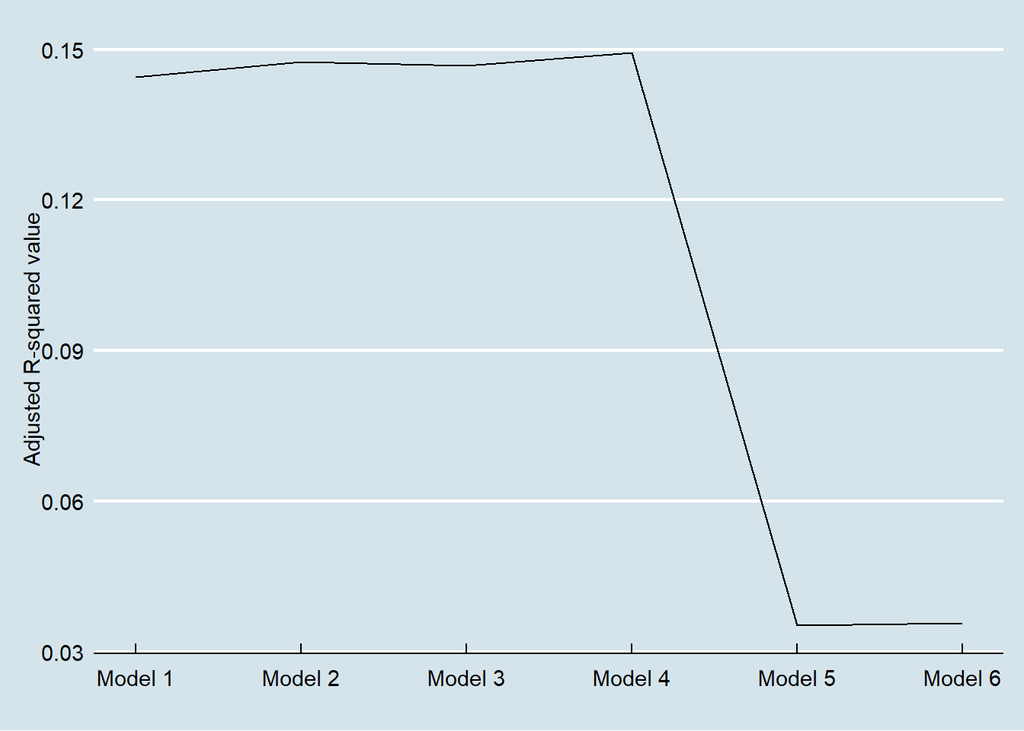

```r
ModelFit <- tibble(model = c(1, 2, 3, 4, 5, 6),
                   R_square = c(summary(model1)$adj.r.squared,
                                summary(model2)$adj.r.squared,
                                summary(model3)$adj.r.squared,
                                summary(model4)$adj.r.squared,
                                summary(model5)$adj.r.squared,
                                summary(model6)$adj.r.squared))

ggplot(ModelFit, aes(x = model, y = R_square)) +
  geom_line() +
  scale_x_continuous(name = "",
                   breaks = breaks <- seq(1, 6, by = 1),
                   labels = paste("Model", breaks)) +
  scale_y_continuous(name = "Adjusted R-squared value") +
  theme_economist()
```

We can see the dip at model 5 and 6. Model 4 is the best fit. On the next step, I will visualize the results on a table.

## Model results on a table

```r
coeff_names <- c("Race American Indian \n Alaska Native \n(Compared to White)" = "RACEAIAN",
                 "Race Asian \n(Compared to White)" = "RACEAsian",
                 "Race Black \n(Compared to White)" = "RACEBlack",
                 "Race Other \n(Compared to White)" = "RACEOther",
                 "Employed \n(Compared to unemployed)" = "ESR_labelEmployed",
                 "Education \nAssociate's degree \n(Compared to high school degree)" = "SCHL_labelAssociate's degree",
                 "Education \nBachelor's degree or Higher \n(Compared to high school degree)" = "SCHL_labelBachelor's degree or Higher",
                 "Education \nNo Schooling Completed \n(Compared to high school degree)" = "SCHL_labelNo Schooling Completed",
                 "Period of naturalization" = "years_to_nat",
                 "Interaction \nPeriod of naturalization and \nAssociate's degree" = "SCHL_labelAssociate's degree:years_to_nat",
                 "Interaction \nPeriod of naturalization and \nBachelor's degree or Higher" = "SCHL_labelBachelor's degree or Higher:years_to_nat",
                 "Interaction \nPeriod of naturalization and \nNo Schooling Completed" = "SCHL_labelNo Schooling Completed:years_to_nat",
                 "Interaction \nEmployed and \nAssociate's degree" = "ESR_labelEmployed:SCHL_labelAssociate's degree",
                 "Interaction \nEmployed and \nBachelor's degree or Higher" = "ESR_labelEmployed:SCHL_labelBachelor's degree or Higher",
                 "Interaction \nEmployed and \nNo Schooling Completed" = "ESR_labelEmployed:SCHL_labelNo Schooling Completed",
                 "Interaction \nAmerican Indian \n Alaska Native \nand Associate's degree" = "RACEAIAN:SCHL_labelAssociate's degree",
                 "Interaction \nAsian \nand Associate's degree" = "RACEAsian:SCHL_labelAssociate's degree",
                 "Interaction \nBlack \nand Associate's degree" = "RACEBlack:SCHL_labelAssociate's degree",
                 "Interaction \nOther \nand Associate's degree" = "RACEOther:SCHL_labelAssociate's degree",
                 "Interaction \nAmerican Indian \n Alaska Native \nand Bachelor's degree or Higher" = "RACEAIAN:SCHL_labelBachelor's degree or Higher",
                 "Interaction \nAsian \nand Bachelor's degree or Higher" = "RACEAsian:SCHL_labelBachelor's degree or Higher",
                 "Interaction \nBlack \nand Bachelor's degree or Higher" = "RACEBlack:SCHL_labelBachelor's degree or Higher",
                 "Interaction \nOther \nand Bachelor's degree or Higher" = "RACEOther:SCHL_labelBachelor's degree or Higher",
                 "Interaction \nAmerican Indian \n Alaska Native \nand No Schooling Completed" = "RACEAIAN:SCHL_labelNo Schooling Completed",
                 "Interaction \nAsian \nand No Schooling Completed" = "RACEAsian:SCHL_labelNo Schooling Completed",
                 "Interaction \nBlack \nand No Schooling Completed" = "RACEBlack:SCHL_labelNo Schooling Completed",
                 "Interaction \nOther \nand No Schooling Completed" = "RACEOther:SCHL_labelNo Schooling Completed")
export_summs(model1, model4,
             error_format = "(p = {p.value})",
             error_pos = "same",
             model.names = c("Initial model", "Preferred model"),
             coefs = coeff_names)
```

|  | Initial model | Preferred model |
| --- | --- | --- |
| Race American Indian Alaska Native (Compared to White) | -12774.95 ** (p = 0.01) | -6870.18 (p = 0.26) |
| Race Asian (Compared to White) | -190.46 (p = 0.84) | -1355.37 (p = 0.36) |
| Race Black (Compared to White) | -7980.63 ** (p = 0.01) | -1397.35 (p = 0.77) |
| Race Other (Compared to White) | -8420.92 *** (p = 0.00) | -3979.43 * (p = 0.01) |
| Employed (Compared to unemployed) | 45598.51 *** (p = 0.00) | 30162.26 *** (p = 0.00) |
| Education Associate's degree (Compared to high school degree) | 13685.52 *** (p = 0.00) | 8578.41 (p = 0.32) |
| Education Bachelor's degree or Higher (Compared to high school degree) | 56615.75 *** (p = 0.00) | 12601.05 * (p = 0.01) |
| Education No Schooling Completed (Compared to high school degree) | -7458.31 *** (p = 0.00) | -396.94 (p = 0.97) |
| Period of naturalization | 106.44 * (p = 0.03) | 6.08 (p = 0.93) |
| Interaction Period of naturalization and Associate's degree |  | -53.18 (p = 0.77) |
| Interaction Period of naturalization and Bachelor's degree or Higher |  | 307.46 ** (p = 0.01) |
| Interaction Period of naturalization and No Schooling Completed |  | -121.14 (p = 0.63) |
| Interaction Employed and Associate's degree |  | 7318.21 (p = 0.37) |
| Interaction Employed and Bachelor's degree or Higher |  | 43918.02 *** (p = 0.00) |
| Interaction Employed and No Schooling Completed |  | -5147.50 (p = 0.64) |
| Interaction American Indian Alaska Native and Associate's degree |  | -3410.56 (p = 0.84) |
| Interaction Asian and Associate's degree |  | -203.31 (p = 0.95) |
| Interaction Black and Associate's degree |  | -3741.03 (p = 0.69) |
| Interaction Other and Associate's degree |  | -4973.04 (p = 0.34) |
| Interaction American Indian Alaska Native and Bachelor's degree or Higher |  | -20112.65 (p = 0.06) |
| Interaction Asian and Bachelor's degree or Higher |  | 1119.40 (p = 0.58) |
| Interaction Black and Bachelor's degree or Higher |  | -14343.60 * (p = 0.03) |
| Interaction Other and Bachelor's degree or Higher |  | -32259.75 *** (p = 0.00) |
| Interaction American Indian Alaska Native and No Schooling Completed |  | -3043.15 (p = 0.89) |
| Interaction Asian and No Schooling Completed |  | -5498.99 (p = 0.33) |
| Interaction Black and No Schooling Completed |  | -13356.89 (p = 0.59) |
| Interaction Other and No Schooling Completed |  | 6555.38 (p = 0.25) |
| N | 31246 | 31246 |
| R2 | 0.14 | 0.15 |
| *** p < 0.001; ** p < 0.01; * p < 0.05. |  |  |

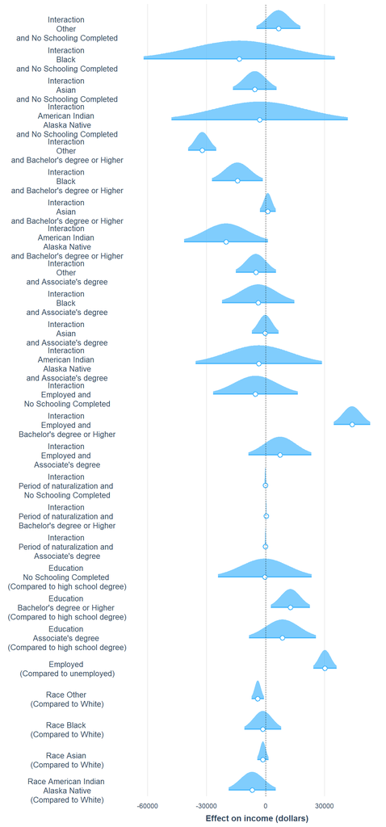

```r
coeff_desc <- c("Race American Indian \n Alaska Native \n(Compared to White)" = "RACEAIAN",
                 "Race Asian \n(Compared to White)" = "RACEAsian",
                 "Race Black \n(Compared to White)" = "RACEBlack",
                 "Race Other \n(Compared to White)" = "RACEOther",
                 "Employed \n(Compared to unemployed)" = "ESR_labelEmployed",
                 "Education \nAssociate's degree \n(Compared to high school degree)" = "SCHL_labelAssociate's degree",
                 "Education \nBachelor's degree or Higher \n(Compared to high school degree)" = "SCHL_labelBachelor's degree or Higher",
                 "Education \nNo Schooling Completed \n(Compared to high school degree)" = "SCHL_labelNo Schooling Completed",
                 "Interaction \nPeriod of naturalization and \nAssociate's degree" = "SCHL_labelAssociate's degree:years_to_nat",
                 "Interaction \nPeriod of naturalization and \nBachelor's degree or Higher" = "SCHL_labelBachelor's degree or Higher:years_to_nat",
                 "Interaction \nPeriod of naturalization and \nNo Schooling Completed" = "SCHL_labelNo Schooling Completed:years_to_nat",
                 "Interaction \nEmployed and \nAssociate's degree" = "ESR_labelEmployed:SCHL_labelAssociate's degree",
                 "Interaction \nEmployed and \nBachelor's degree or Higher" = "ESR_labelEmployed:SCHL_labelBachelor's degree or Higher",
                 "Interaction \nEmployed and \nNo Schooling Completed" = "ESR_labelEmployed:SCHL_labelNo Schooling Completed",
                 "Interaction \nAmerican Indian \n Alaska Native \nand Associate's degree" = "RACEAIAN:SCHL_labelAssociate's degree",
                 "Interaction \nAsian \nand Associate's degree" = "RACEAsian:SCHL_labelAssociate's degree",
                 "Interaction \nBlack \nand Associate's degree" = "RACEBlack:SCHL_labelAssociate's degree",
                 "Interaction \nOther \nand Associate's degree" = "RACEOther:SCHL_labelAssociate's degree",
                 "Interaction \nAmerican Indian \n Alaska Native \nand Bachelor's degree or Higher" = "RACEAIAN:SCHL_labelBachelor's degree or Higher",
                 "Interaction \nAsian \nand Bachelor's degree or Higher" = "RACEAsian:SCHL_labelBachelor's degree or Higher",
                 "Interaction \nBlack \nand Bachelor's degree or Higher" = "RACEBlack:SCHL_labelBachelor's degree or Higher",
                 "Interaction \nOther \nand Bachelor's degree or Higher" = "RACEOther:SCHL_labelBachelor's degree or Higher",
                 "Interaction \nAmerican Indian \n Alaska Native \nand No Schooling Completed" = "RACEAIAN:SCHL_labelNo Schooling Completed",
                 "Interaction \nAsian \nand No Schooling Completed" = "RACEAsian:SCHL_labelNo Schooling Completed",
                 "Interaction \nBlack \nand No Schooling Completed" = "RACEBlack:SCHL_labelNo Schooling Completed",
                 "Interaction \nOther \nand No Schooling Completed" = "RACEOther:SCHL_labelNo Schooling Completed")

plot_coefs(model4,
           coefs = coeff_desc,
           plot.distributions = TRUE,
           rescale.distributions = TRUE) +
  scale_x_continuous(name = "Effect on income (dollars)")
```

## Visualizing education and income

I will now visualize education and income, by employment, holding all the other variables at their means.

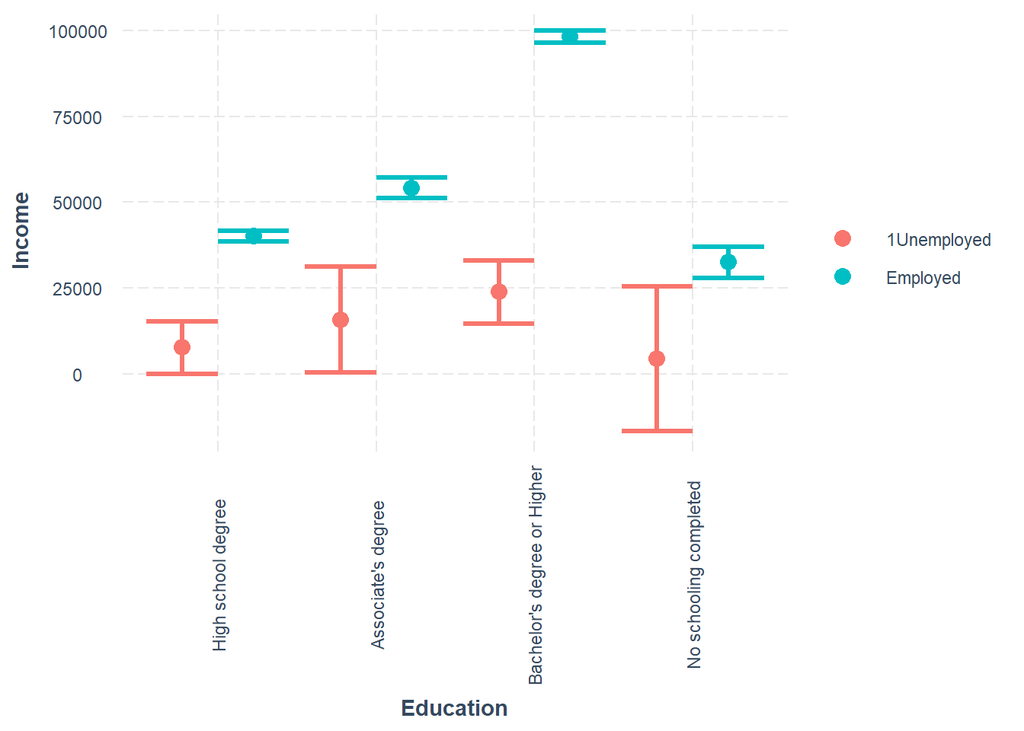

```r
cat_plot(model3, pred = SCHL_label, modx = ESR_label, interval = TRUE) +
 scale_x_discrete(name = "Education",
                    labels = c("High school degree", "Associate's degree",
                               "Bachelor's degree or Higher", "No schooling completed")) +
  scale_color_discrete(name = "") +
  scale_linetype_discrete(name = "") +
  theme(axis.text.x = element_text(angle = 90)) +
  scale_fill_discrete(name = "") +
  theme(axis.text.x = element_text(angle = 90)) +
  scale_y_continuous(name = "Income",
                     breaks = seq(-25000, 100000, by = 25000))
```

Next steps: I will try to simplify the categories for education, and run the regression models.